# R Notebook for Nonlinear OLS Regression

# Part 1: Nonlinear OLS Modesl via variable transformation

## Load Libraries

```r
library(tidyverse)
library(olsrr)
library(modelr)
library(psych)
library(GGally)
```

## Transforming inches to cenitmeters (and graph)

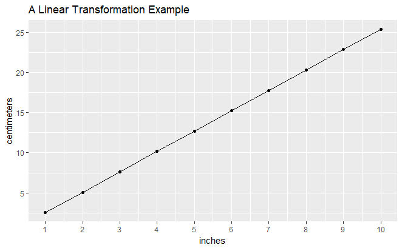

```r
trans1 <- tibble(inches = 1:10, centimeters = inches*2.54)
ggplot(trans1, aes(x = inches, y = centimeters)) +
geom_line() +
geom_point() +
scale_x_continuous(breaks = c(1:10)) +
labs (title = "A Linear Transformation Example")
```

## Non-Linear Tranfromation:

### Base 2 log transformation

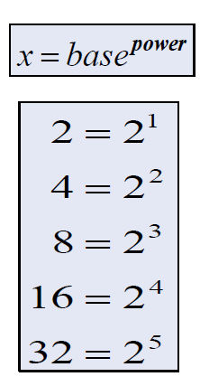

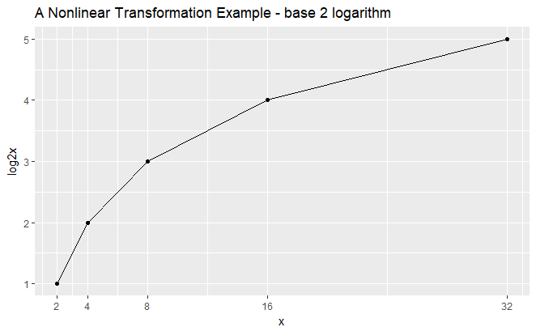

```r
trans2 <- tibble(x = c(2,4,8,16,32), log2x = log2(x))
ggplot(trans2, aes(x = x, y = log2x)) +
geom_line() +
geom_point() +
scale_x_continuous(breaks = c(2,4,8,16,32)) +
labs (title = "A Nonlinear Transformation Example - base 2 logarithm")
```

### Base 10 logarithm transformation

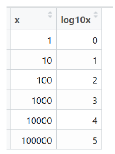

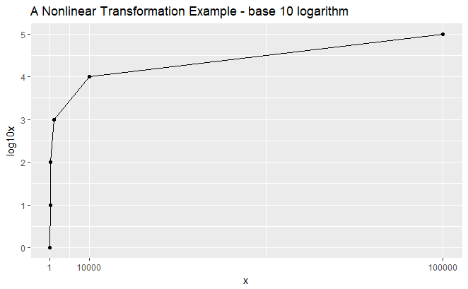

```r
options(scipen = 999) # disable scientific notation
trans3 <- tibble(x = c(1,10,100,1000,10000,100000), log10x = log10(x))
ggplot(trans3, aes(x = x, y = log10x)) +
geom_line() +
geom_point() +
scale_x_continuous(breaks = c(1,10000,100000)) +
labs (title = "A Nonlinear Transformation Example - base 10 logarithm")
```

### Natural logarithm transformation (most used)

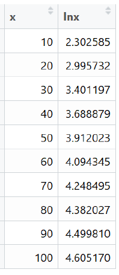

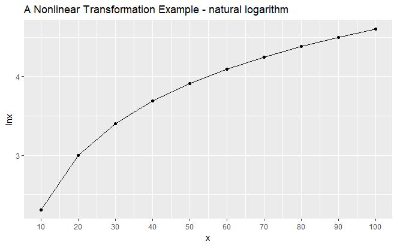

```r
trans4 <- tibble(x = seq(10,100, by = 10), lnx = log(x))
ggplot(trans4, aes(x = x, y = lnx)) +
geom_line() +
geom_point() +
scale_x_continuous(breaks = seq(10,100, by = 10)) +
labs (title = "A Nonlinear Transformation Example - natural logarithm")
```

# Scatter plot matrix

Notice how GDP and Footp are positively skewed… it’s evidence of needing a transformation

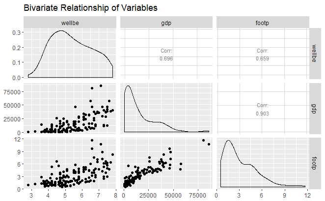

```r
# read in data
hp <- read_csv("happyplanet.csv")
# create a scatterplot matrix
scatterplot <- ggpairs(hp, columns = c("wellbe", "gdp", "footp"),
upper = list(continuous = wrap("cor", size=3)),
title = "Bivariate Relationship of Variables")
print(scatterplot, progress=FALSE )
```

## Example of ln(x), orginal y

### Create a scatterplot of GDP of GDP & well-being - overlay linear model

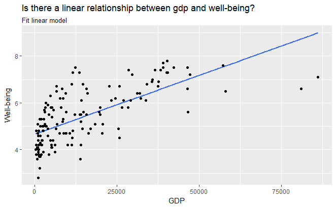

```r
ggplot(hp, aes(x = gdp, y = wellbe)) +
geom_smooth(method = lm, se = FALSE) +
geom_point() +
labs(title = "Is there a linear relationship between gdp and well-being?",
subtitle = "Fit linear model",
x = "GDP", y = "Well-being")
```

### Create a scatterplot of GDP and well-being - apply loess smoother

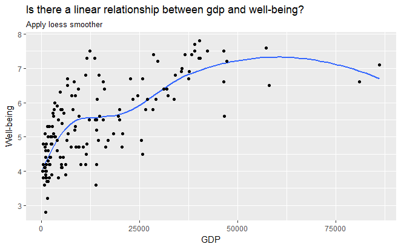

```r
ggplot(hp, aes(x = gdp, y = wellbe)) +
geom_smooth(method = "loess", se = FALSE) + #<- Notice the "loess" smoother, this is the newest thing to this.
geom_point() +
labs(title = "Is there a linear relationship between gdp and well-being?",
subtitle = "Apply loess smoother",
x = "GDP", y = "Well-being")
```

### Create a scatterplot of ln(GDP) and wellbeing

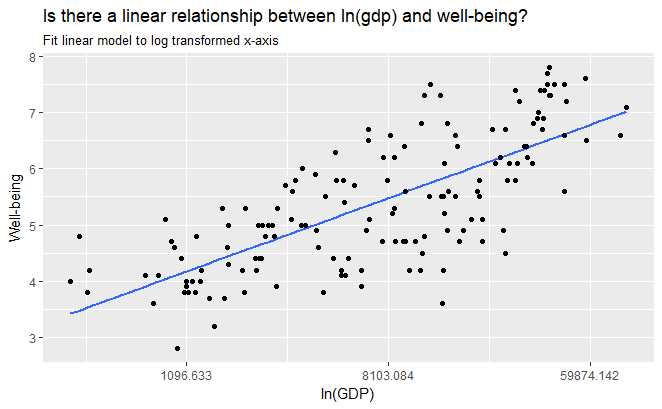

```r
ggplot(hp, aes(x = gdp, y = wellbe)) +
geom_smooth(method = lm, se = FALSE) +
geom_point() +
scale_x_continuous(trans = "log") + #<- this is transforming the variable within GGplot
labs(title = "Is there a linear relationship between ln(gdp) and well-being?",
subtitle = "Fit linear model to log transformed x-axis",
x = "ln(GDP)", y = "Well-being")
```

### Log transform GDP and fit linear regression model

```r
# take the natural log transformation of gdp
hp <- mutate(hp, lngdp = log(gdp))
# fit the simple linear regression
logx <- lm(data = hp, wellbe ~ lngdp)
ols_regress(logx)
```

```
                        Model Summary
--------------------------------------------------------------
R                       0.737       RMSE                0.794
R-Squared               0.542       Coef. Var          14.712
Adj. R-Squared          0.539       MSE                 0.631
Pred R-Squared          0.532       MAE                 0.655
--------------------------------------------------------------
 RMSE: Root Mean Square Error
 MSE: Mean Square Error
 MAE: Mean Absolute Error

                                ANOVA
---------------------------------------------------------------------
               Sum of
              Squares         DF    Mean Square       F         Sig.
---------------------------------------------------------------------
Regression    111.415          1        111.415    176.654    0.0000
Residual       93.974        149          0.631
Total         205.389        150
---------------------------------------------------------------------

                                  Parameter Estimates
---------------------------------------------------------------------------------------
      model      Beta    Std. Error    Std. Beta      t        Sig      lower    upper
---------------------------------------------------------------------------------------
(Intercept)    -0.385         0.440                 -0.874    0.383    -1.254    0.485
      lngdp     0.651         0.049        0.737    13.291    0.000     0.554    0.748
---------------------------------------------------------------------------------------
```

### Function to interprety regression sloipe for ln transformed x, original y

```r
ln.x <- function(slope, x_chg) {
new_slope <- slope * (log(1 + (x_chg/100)))
return(new_slope)
}
```

### Use function.x to interpret parameters

```r
ln.x(slope = .651, x_chg = 1) #slope = whatever your slope is. x_change = whatever percet change you want increase you want to look at it in.
```

```
[1] 0.006477665
```

```r
ln.x(slope = logx$coefficients["lngdp"], x_chg = 1) #here is the same thing, but you are actually referring to the coefficient table from you regression table.
```

```
      lngdp
0.006480771
```

A 1% increase is in GDP is associated with a 0.006 unit increase in the average well-being score of resident s in the country.

```r
ln.x(slope = logx$coefficients["lngdp"], x_chg = 100) #100 = a doubling of GDP
```

```
    lngdp
0.4514551
```

### Visualize the nonlinear relationship

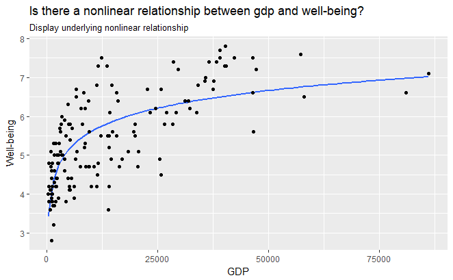

```r
# create a scatterplot of GDP and wellbeing - represent the underlying nonlinear curve
ggplot(hp, aes(x = gdp, y = wellbe)) +
geom_smooth(method = lm, se = FALSE, formula = y ~ 1 + log(x)) +
geom_point() +
labs(title = "Is there a nonlinear relationship between gdp and well-being?",
subtitle = "Display underlying nonlinear relationship",
x = "GDP", y = "Well-being")
```

## Example of ln(y), original x

### Fit regression model

```r
logy <- lm(data = hp, lngdp ~ wellbe)
ols_regress(logy)
```

```
                        Model Summary
--------------------------------------------------------------
R                       0.737       RMSE                0.898
R-Squared               0.542       Coef. Var          10.115
Adj. R-Squared          0.539       MSE                 0.807
Pred R-Squared          0.532       MAE                 0.745
--------------------------------------------------------------
 RMSE: Root Mean Square Error
 MSE: Mean Square Error
 MAE: Mean Absolute Error

                                ANOVA
---------------------------------------------------------------------
               Sum of
              Squares         DF    Mean Square       F         Sig.
---------------------------------------------------------------------
Regression    142.473          1        142.473    176.654    0.0000
Residual      120.170        149          0.807
Total         262.644        150
---------------------------------------------------------------------

                                 Parameter Estimates
-------------------------------------------------------------------------------------
      model     Beta    Std. Error    Std. Beta      t        Sig     lower    upper
-------------------------------------------------------------------------------------
(Intercept)    4.383         0.346                 12.664    0.000    3.699    5.066
     wellbe    0.833         0.063        0.737    13.291    0.000    0.709    0.957
-------------------------------------------------------------------------------------
```

#### Getting the original metric

```r
#to get the slope we can exponentiate the intercept and log to see where they fit in the original metric
exp(4.383)
```

```
[1] 80.07791
```

##### Fubnction for the slope

```r
ln.y <- function(slope, x_chg) {
new_slope <- 100 * (exp(slope * x_chg) - 1)
return(new_slope)
}
ln.y(slope = .833, x_chg = 1)
```

```
[1] 130.0209
```

```r
ln.y(slope = logy$coefficients["wellbe"], x_chg = 1)
```

```
  wellbe
129.9913
```

A 1 unit increase in wellbe is associated with a 130% increase in GDP.

```r
#find predicted gdp at well being of unit of 4 and 5
pre4 <- predict(logy, data.frame(wellbe = 4))
pre5 <- predict(logy, data.frame(wellbe = 5))
#exponentiate it so it is at normal units
exp(pre4)
```

```
       1
2239.619
```

```r
exp(pre5)
```

```
       1
5150.928
```

```r
#Get the percent difference between the two.
(5150.917-2239.617)/2239.617
```

```
[1] 1.29991
```

```r
#Notice how this number is exactly the same as our ln.y function above.
```

## example of ln(y), ln(x)

### Transform footp and create a scatterplot matrix of the raw and transformed variables

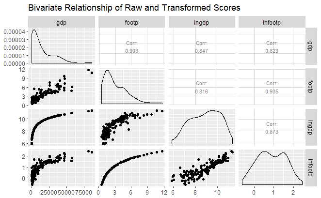

```r
hp <- mutate(hp, lnfootp = log(footp))
scatterplot <- ggpairs(hp, columns = c("gdp", "footp", "lngdp", "lnfootp"),
upper = list(continuous = wrap("cor", size=3)),
title = "Bivariate Relationship of Raw and Transformed Scores")
print(scatterplot, progress=FALSE )
```

### Fit regression model

```r
logxy <- lm(data = hp, lnfootp ~ lngdp)
ols_regress(logxy)
```

```
                        Model Summary
--------------------------------------------------------------
R                       0.873       RMSE                0.343
R-Squared               0.762       Coef. Var          38.701
Adj. R-Squared          0.761       MSE                 0.117
Pred R-Squared          0.755       MAE                 0.264
--------------------------------------------------------------
 RMSE: Root Mean Square Error
 MSE: Mean Square Error
 MAE: Mean Absolute Error

                                ANOVA
---------------------------------------------------------------------
               Sum of
              Squares         DF    Mean Square       F         Sig.
---------------------------------------------------------------------
Regression     56.045          1         56.045    477.702    0.0000
Residual       17.481        149          0.117
Total          73.526        150
---------------------------------------------------------------------

                                   Parameter Estimates
-----------------------------------------------------------------------------------------
      model      Beta    Std. Error    Std. Beta       t        Sig      lower     upper
-----------------------------------------------------------------------------------------
(Intercept)    -3.216         0.190                 -16.954    0.000    -3.591    -2.841
      lngdp     0.462         0.021        0.873     21.856    0.000     0.420     0.504
-----------------------------------------------------------------------------------------
```

# Function for log tranformed x & y

```r
ln.xy <- function(slope, x_chg) {
new_slope <- 100 * (exp(slope * (log(1 + (x_chg/100))))-1)
return(new_slope)
}
ln.xy(slope = .462, x_chg = 100)
```

```
[1] 37.745
```

```r
ln.xy(slope = logxy$coefficients["lngdp"], x_chg = 100)
```

```
   lngdp
37.73926
```

A 100% increase in GDP is associated with a 38% increase in the ecological footprint.

```r
# get log of 50,000
log(50000)
```

```
[1] 10.81978
```

```r
# get y-hat when gdp = 50,000
predict (logxy, data.frame(lngdp=10.81978))
```

```
       1
1.781842
```

```r
# back transform
exp(1.781842)
```

```
[1] 5.940789
```

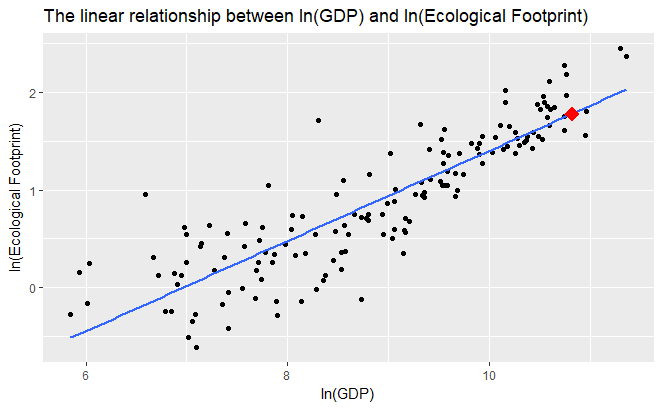

```r
# create a scatterplot of ln(GDP) and ln(footp)
ggplot(hp, aes(x = lngdp, y = lnfootp)) +
geom_point() +
geom_smooth(method = lm, se = FALSE) +
annotate("point", x = 10.82, y = 1.78, colour = "red", size = 5, shape = 18) +
labs(title = "The linear relationship between ln(GDP) and ln(Ecological Footprint)", x = "ln(GDP)", y = "ln(Ecological Footprint)")
```

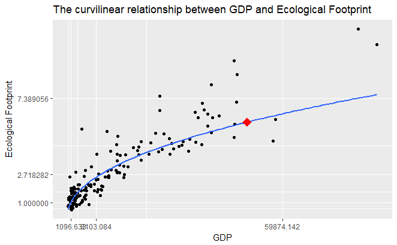

```r
# create a scatterplot of GDP and footp
ggplot(hp, aes(x = gdp, y = footp)) +
geom_point() +
scale_x_continuous(trans = "log") +
scale_y_continuous(trans = "log") +
geom_smooth(method = lm, se = FALSE) +
coord_trans(x = "exp", y = "exp") +
annotate("point", x = 50000, y = 5.94, colour = "red", size = 5, shape = 18) +
labs(title = "The curvilinear relationship between GDP and Ecological Footprint", x = "GDP", y = "Ecological Footprint")
```

# Part 2: Nonlinear OLS models via polynomialss

## Import Data: Cogtest file

Suppose that we are interested in the effect of time spent in practice on the performance of a visual discrimination task. Subjects are randomly assigned to different levels of practice, following which a test of visual discrimination is administered, and the number of correct responses is recorded for each subject. 40 subjects were randomly assigned to practice 0 minutes, 2 minutes, 4 minutes, 6 minutes, 8 minutes, 10 minutes, 12 minutes, or 14 minutes. There are two variables:

1. practice - minutes spent practicing, this was assigned by the experimenter
2. score - the number of correct answers on the test

```r
cogtest <- read_csv("cogtest.csv")
```

## Overlay a linear function

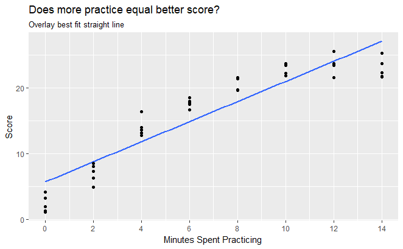

```r
# plot data with best fit straight line
ggplot(cogtest, aes(x = practice, y = score)) +
  geom_smooth(method = "lm", se = FALSE) +
  geom_point() +
  scale_x_continuous(limits=c(0,14), breaks = seq(0, 14, by = 2)) +
  labs(title = "Does more practice equal better score?",
  subtitle = "Overlay best fit straight line",
  x = "Minutes Spent Practicing", y = "Score")
```

## Overlay a Quadratic function

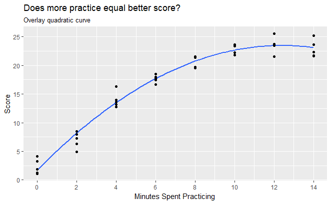

```r
# plot data with quadratic function
ggplot(cogtest, aes(x = practice, y = score)) +
  geom_smooth(method = "lm", formula = y ~ poly(x, 2), se = FALSE) +
  geom_point() +
  scale_x_continuous(limits=c(0,14), breaks = seq(0, 14, by = 2)) +
  labs(title = "Does more practice equal better score?",
  subtitle = "Overlay quadratic curve",
  x = "Minutes Spent Practicing", y = "Score")
```

## Prepare polynomial terms

```r
cogtest <- mutate(cogtest,
practice2 = practice^2,
practice3 = practice^3)
```

## Fit a linear Model

```r
lm_lin <- lm(data = cogtest, score ~ practice)
ols_regress(lm_lin)
```

```
                        Model Summary
--------------------------------------------------------------
R                       0.925       RMSE                2.952
R-Squared               0.856       Coef. Var          18.017
Adj. R-Squared          0.852       MSE                 8.713
Pred R-Squared          0.837       MAE                 2.512
--------------------------------------------------------------
 RMSE: Root Mean Square Error
 MSE: Mean Square Error
 MAE: Mean Absolute Error

                                ANOVA
---------------------------------------------------------------------
                Sum of
               Squares        DF    Mean Square       F         Sig.
---------------------------------------------------------------------
Regression    1964.353         1       1964.353    225.462    0.0000
Residual       331.078        38          8.713
Total         2295.431        39
---------------------------------------------------------------------

                                 Parameter Estimates
-------------------------------------------------------------------------------------
      model     Beta    Std. Error    Std. Beta      t        Sig     lower    upper
-------------------------------------------------------------------------------------
(Intercept)    5.678         0.852                  6.664    0.000    3.953    7.403
   practice    1.529         0.102        0.925    15.015    0.000    1.323    1.735
-------------------------------------------------------------------------------------
```

## Fit a quadractic model

```r
lm_quad <- lm(data = cogtest, score ~ practice + practice2)
ols_regress(lm_quad)
```

```
                        Model Summary
-------------------------------------------------------------
R                       0.987       RMSE               1.276
R-Squared               0.974       Coef. Var          7.787
Adj. R-Squared          0.972       MSE                1.627
Pred R-Squared          0.969       MAE                0.945
-------------------------------------------------------------
 RMSE: Root Mean Square Error
 MSE: Mean Square Error
 MAE: Mean Absolute Error

                                ANOVA
---------------------------------------------------------------------
                Sum of
               Squares        DF    Mean Square       F         Sig.
---------------------------------------------------------------------
Regression    2235.214         2       1117.607    686.706    0.0000
Residual        60.217        37          1.627
Total         2295.431        39
---------------------------------------------------------------------

                                   Parameter Estimates
-----------------------------------------------------------------------------------------
      model      Beta    Std. Error    Std. Beta       t        Sig      lower     upper
-----------------------------------------------------------------------------------------
(Intercept)     1.703         0.480                   3.547    0.001     0.730     2.676
   practice     3.517         0.160        2.127     21.949    0.000     3.192     3.841
  practice2    -0.142         0.011       -1.250    -12.901    0.000    -0.164    -0.120
-----------------------------------------------------------------------------------------
```

## Fit a cubic Model

```r
lm_cubic <- lm(data = cogtest, score ~ practice + practice2 + practice3)
ols_regress(lm_cubic)
```

```
                        Model Summary
-------------------------------------------------------------
R                       0.987       RMSE               1.270
R-Squared               0.975       Coef. Var          7.750
Adj. R-Squared          0.973       MSE                1.612
Pred R-Squared          0.968       MAE                0.922
-------------------------------------------------------------
 RMSE: Root Mean Square Error
 MSE: Mean Square Error
 MAE: Mean Absolute Error

                                ANOVA
---------------------------------------------------------------------
                Sum of
               Squares        DF    Mean Square       F         Sig.
---------------------------------------------------------------------
Regression    2237.395         3        745.798    462.622    0.0000
Residual        58.036        36          1.612
Total         2295.431        39
---------------------------------------------------------------------

                                  Parameter Estimates
---------------------------------------------------------------------------------------
      model      Beta    Std. Error    Std. Beta      t        Sig      lower    upper
---------------------------------------------------------------------------------------
(Intercept)     1.988         0.537                  3.703    0.001     0.899    3.077
   practice     3.144         0.358        1.902     8.786    0.000     2.418    3.870
  practice2    -0.071         0.062       -0.624    -1.140    0.262    -0.197    0.055
  practice3    -0.003         0.003       -0.416    -1.163    0.252    -0.009    0.003
---------------------------------------------------------------------------------------
```

## Johnson-Neyman Graph

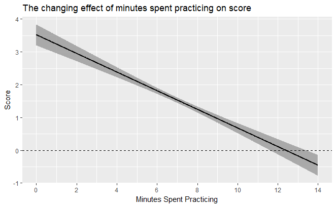

```r
tcrit = qt(c(.025, .975), df = 38)
varmat <- as.matrix(vcov(lm_quad))
vbx <- varmat["practice","practice"]
vbx2 <- varmat["practice2","practice2"]
vbxx2 <- varmat["practice","practice2"]
slopes <- cogtest %>%
data_grid(practice)
slopes <- mutate(slopes, tangent_slope = lm_quad$coefficients["practice"] + 2*lm_quad$coefficients["practice2"]*practice,
se = sqrt(vbx+(4*practice*vbxx2)+((4*practice^2)*vbx2)),
lwr = tangent_slope - tcrit*se,
upr = tangent_slope + tcrit*se,
tstar = tangent_slope/se)
slopes_plot <- cogtest %>%
data_grid(practice = seq_range(practice, 1000))
slopes_plot <- mutate(slopes_plot, tangent_slope = lm_quad$coefficients["practice"] + 2*lm_quad$coefficients["practice2"]*practice,
se = sqrt(vbx+(4*practice*vbxx2)+((4*practice^2)*vbx2)),
lwr = tangent_slope - tcrit*se,
upr = tangent_slope + tcrit*se,
tstar = tangent_slope/se)
ggplot(slopes_plot, aes(x = practice, y = tangent_slope)) +
geom_line() +
geom_ribbon(aes(ymin = lwr, ymax = upr, color = NULL), alpha = .8, fill = "grey60") +
geom_line(size = 1) +
geom_hline(yintercept=0, linetype=2) +
scale_x_continuous(limits=c(0,14), breaks = seq(0, 14, by = 2)) +
labs(title = "The changing effect of minutes spent practicing on score",
x = "Minutes Spent Practicing", y = "Score")
```

```r
# Calculate vertex
vertex = -lm_quad$coefficients["practice"]/(2*lm_quad$coefficients["practice2"])
print(vertex)
```

```
practice
12.38601
```